# EFFDIS Effort Estimation

# Relationship (sum of products) between Task 1 (the total catches of 9 major tuna & tuna-like species) and Task 2 (much more detailed) data for all fleet combinations

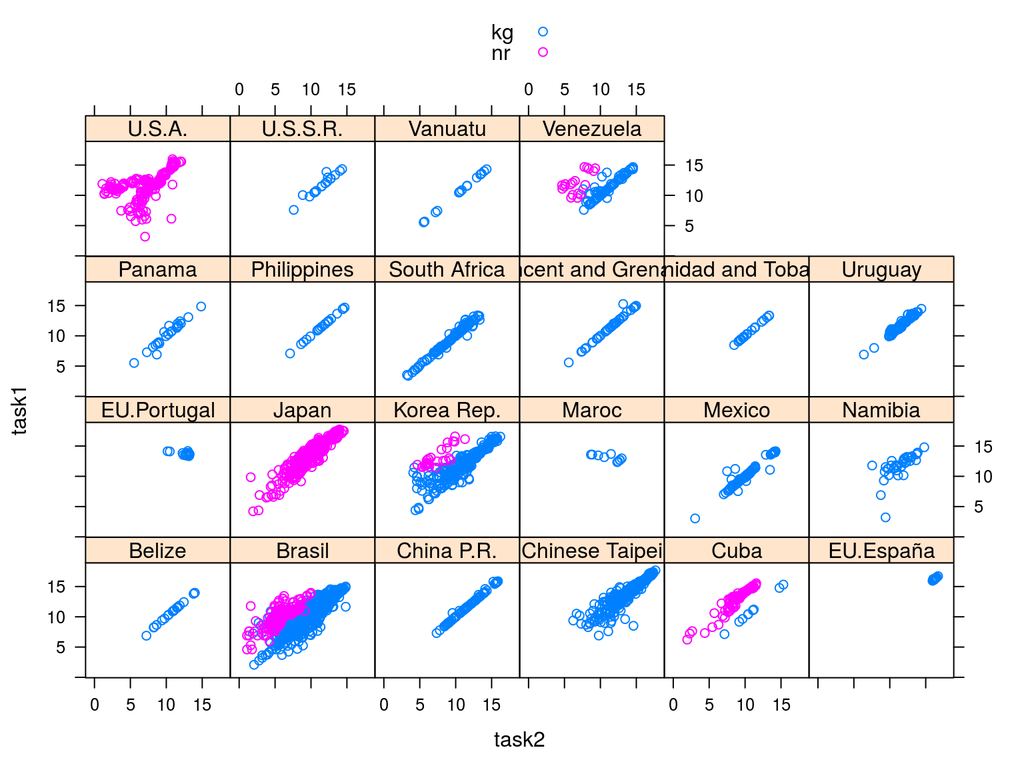

# Developing multivariate models. Swordfish modeled (GAM) as function of space and time - Chinese Taipei for June 2009

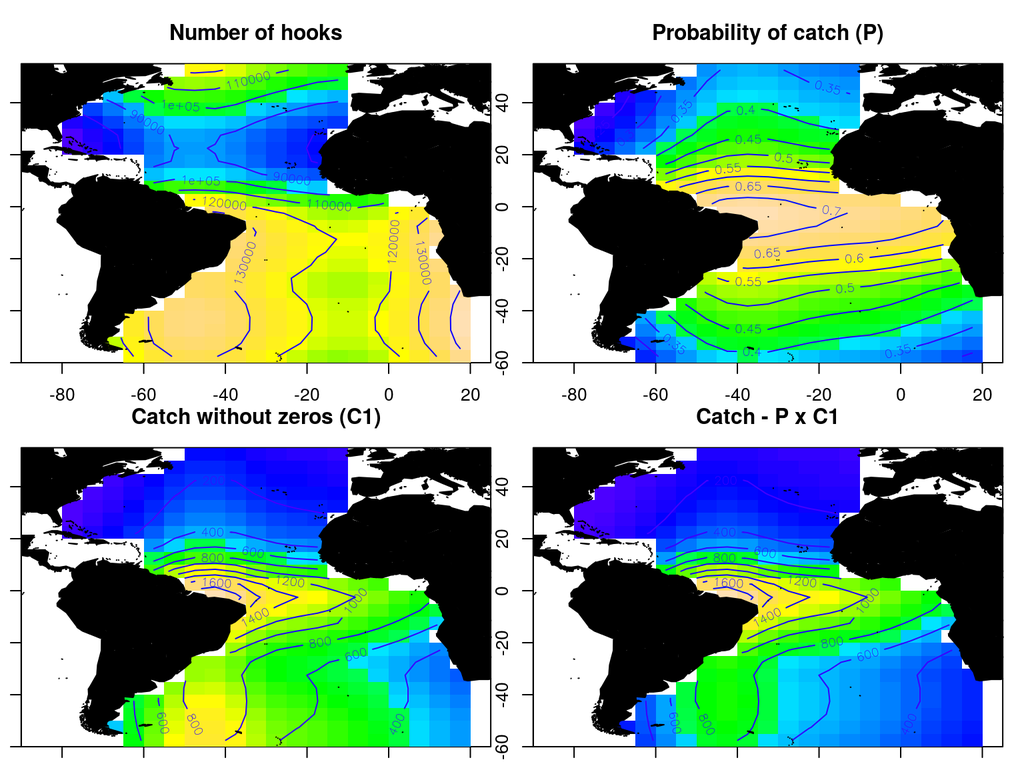

# Conclusions

- The project only recently started and the data are complex and the Contractor is working to understand the nuances
- There is non-random, non-representative sampling
- There is a strong positive correlation between Task 1 and Task 2 data for most countries which is useful information
- Provision of numbers for Task 2 (instead of weights) by e.g. USA creates problems
- Regression modeling is a promising approach
- A series of models can be fitted to the data and used for interpolation and variance estimation